### Notas de aula de Mecânica Quântica Autor: Jonas Maziero

# Teoria de perturbação

O objetivo da teoria de perturbação é construir soluções aproximadas (estáticas ou dinâmicas) a partir das soluções analíticas obtidas em casos particulares, que geralmente estão relacionados com intensidades de interação maiores em relação às correções que queremos incluir.

# Teoria de perturbação independente do tempo Espectros discretos degenerados

Consideremos agora o problema \begin{equation} H|\psi_{n}\rangle = E_{n}|\psi_{n}\rangle \end{equation} com \begin{equation} H=H_{0}+H_{1} \end{equation} e \begin{equation} H_{0}|\psi_{n,k}^{(0)}\rangle = E_{n}^{(0)}|\psi_{n,k}^{(0)}\rangle \end{equation} para $k=1,\cdots,d_{n}$. Ou seja, para um dado $n$, exitem $d_{n}$ autovetores $|\psi_{n,k}^{(0)}\rangle$ que correspondem a um mesmo autovalor $E_{n}^{(0)}$.

O desenvolvimento aqui é similar ao caso não degenerado. Consideremos um autovetor qualquer correspondente a $E_{n}^{(0)}$: \begin{equation} |\psi_{n}^{(0)}\rangle = \sum_{k=1}^{d_{n}}c_{n,k}|\psi_{n,k}^{(0)}\rangle. \end{equation} Note que este autovetor pode ser escrito como a combinação linear de uma base ortonormal qualquer do subespaço degenerado correspondente. Começamos escrevendo \begin{equation} |\psi_{n}\rangle = N_{n}\left(|\psi_{n}^{(0)}\rangle + |\chi_{n}\rangle \right) = N_{n}\left(\sum_{k=1}^{d_{n}}c_{n,k}|\psi_{n,k}^{(0)}\rangle + |\chi_{n}\rangle \right) \end{equation} com \begin{equation} \langle\psi_{n,k}^{(0)}|\chi_{n}\rangle=0 \text{ }\forall k. \end{equation} Fazendo \begin{equation} H\rightarrow H_{0}+\xi H_{1}, \end{equation} com $\xi\in[0,1]$, e substituindo na equação característica geral, vem que \begin{align} & E_{n}|\psi_{n}\rangle = E_{n}N_{n}\left(\sum_{k=1}^{d_{n}}c_{n,k}|\psi_{n,k}^{(0)}\rangle + |\chi_{n}\rangle \right) \\ & = H|\psi_{n}\rangle = (H_{0}+\xi H_{1})N_{n}\left(\sum_{k=1}^{d_{n}}c_{n,k}|\psi_{n,k}^{(0)}\rangle + |\chi_{n}\rangle \right) \\ & = N_{n}\left(E_{n}^{(0)}\sum_{k=1}^{d_{n}}c_{n,k}|\psi_{n,k}^{(0)}\rangle + H_{0}|\chi_{n}\rangle + \xi\sum_{k=1}^{d_{n}}c_{n,k}H_{1}|\psi_{n,k}^{(0)}\rangle + \xi H_{1}|\chi_{n}\rangle \right). \end{align}

Dividindo esta equação por $N_{n}$ e a rearranjando, obtemos \begin{equation} (E_{n}-E_{n}^{(0)})\sum_{k=1}^{d_{n}}c_{n,k}|\psi_{n,k}^{(0)}\rangle = \xi \sum_{k=1}^{d_{n}}c_{n,k}H_{1}|\psi_{n,k}^{(0)}\rangle + (H_{0}+\xi H_{1}-E_{n})|\chi_{n}\rangle. \hspace{1cm}(\star) \end{equation}

Tomando o produto interno de $|\psi_{n,l}^{(0)}\rangle$ com a eq. ($\star$), vem que \begin{align} & (E_{n}-E_{n}^{(0)})\sum_{k=1}^{d_{n}}c_{n,k}\langle\psi_{n,l}^{(0)}|\psi_{n,k}^{(0)}\rangle = \xi \sum_{k=1}^{d_{n}}c_{n,k}\langle\psi_{n,l}^{(0)}|H_{1}|\psi_{n,k}^{(0)}\rangle + \langle\psi_{n,l}^{(0)}|H_{0}|\chi_{n}\rangle+\xi \langle\psi_{n,l}^{(0)}|H_{1}|\chi_{n}\rangle-E_{n}\langle\psi_{n,l}^{(0)}|\chi_{n}\rangle \\ & \therefore (E_{n}-E_{n}^{(0)})\sum_{k=1}^{d_{n}}c_{n,k}\delta_{lk} = \xi \sum_{k=1}^{d_{n}}c_{n,k}\langle\psi_{n,l}^{(0)}|H_{1}|\psi_{n,k}^{(0)}\rangle + E_{n}^{(0)}\langle\psi_{n,l}^{(0)}|\chi_{n}\rangle + \xi \langle\psi_{n,l}^{(0)}|H_{1}|\chi_{n}\rangle -E_{n}0 \\ & \therefore (E_{n}-E_{n}^{(0)})c_{n,l} = \xi \sum_{k=1}^{d_{n}}c_{n,k}\langle\psi_{n,l}^{(0)}|H_{1}|\psi_{n,k}^{(0)}\rangle + 0 + \xi\langle\psi_{n,l}^{(0)}|H_{1}|\chi_{n}\rangle. \hspace{1cm} (*) \end{align}

Mais uma vez, escrevemos $|\chi_{n}\rangle$ em uma base de autovetores de $H_{0}$: \begin{equation} |\chi_{n}\rangle = \sum_{m}\sum_{j=1}^{d_{m}}\langle\psi_{m,j}^{(0)}|\chi_{n}\rangle|\psi_{m,j}^{(0)}\rangle \equiv \sum_{m\ne n}\sum_{j=1}^{d_{m}}\langle\psi_{m,j}^{(0)}|\chi_{n}\rangle|\psi_{m,j}^{(0)}\rangle. \end{equation} Para obter os coeficientes tomamos o produto interno de $|\psi_{m,j}^{(0)}\rangle$ com a eq. $(\star)$ para $m\ne n$: \begin{align} & (E_{n}-E_{n}^{(0)})\sum_{k=1}^{d_{n}}c_{n,k}\langle\psi_{m,j}^{(0)}|\psi_{n,k}^{(0)}\rangle = \xi \sum_{k=1}^{d_{n}}c_{n,k}\langle\psi_{m,j}^{(0)}|H_{1}|\psi_{n,k}^{(0)}\rangle + \langle\psi_{m,j}^{(0)}|H_{0}|\chi_{n}\rangle +\xi \langle\psi_{m,j}^{(0)}|H_{1}|\chi_{n}\rangle -E_{n}\langle\psi_{m,j}^{(0)}|\chi_{n}\rangle \\ & \therefore 0 = \xi \sum_{k=1}^{d_{n}}c_{n,k}\langle\psi_{m,j}^{(0)}|H_{1}|\psi_{n,k}^{(0)}\rangle + E_{m}^{(0)}\langle\psi_{m,j}^{(0)}|\chi_{n}\rangle +\xi \langle\psi_{m,j}^{(0)}|H_{1}|\chi_{n}\rangle -E_{n}\langle\psi_{m,j}^{(0)}|\chi_{n}\rangle. \end{align} Teremos assim que \begin{equation} \langle\psi_{m,j}^{(0)}|\chi_{n}\rangle = \xi\sum_{k=1}^{d_{n}}\frac{c_{n,k}\langle\psi_{m,j}^{(0)}|H_{1}|\psi_{n,k}^{(0)}\rangle}{E_{n}-E_{m}^{(0)}} + \xi\frac{\langle\psi_{m,j}^{(0)}|H_{1}|\chi_{n}\rangle}{E_{n}-E_{m}^{(0)}}. \end{equation} e com isso vem que \begin{equation} |\chi_{n}\rangle = \xi\sum_{m\ne n}\sum_{j=1}^{d_{m}}\sum_{k=1}^{d_{n}}\frac{c_{n,k}\langle\psi_{m,j}^{(0)}|H_{1}|\psi_{n,k}^{(0)}\rangle}{E_{n}-E_{m}^{(0)}}|\psi_{m,j}^{(0)}\rangle + \xi\sum_{m\ne n}\sum_{j=1}^{d_{m}}\frac{\langle\psi_{m,j}^{(0)}|H_{1}|\chi_{n}\rangle}{E_{n}-E_{m}^{(0)}}|\psi_{m,j}^{(0)}\rangle. \end{equation}

Iterando, obteremos \begin{align} |\chi_{n}\rangle & = \xi\sum_{m\ne n}\sum_{j=1}^{d_{m}}\sum_{k=1}^{d_{n}}\frac{c_{n,k}\langle\psi_{m,j}^{(0)}|H_{1}|\psi_{n,k}^{(0)}\rangle}{E_{n}-E_{m}^{(0)}}|\psi_{m,j}^{(0)}\rangle \\ & \hspace{0.5cm} + \xi^{2}\sum_{m\ne n}\sum_{j=1}^{d_{m}}\sum_{m'\ne n}\sum_{j'=1}^{d_{m}}\sum_{k=1}^{d_{n}}\frac{c_{n,k}\langle\psi_{m,j}^{(0)}|H_{1}|\psi_{m',j'}^{(0)}\rangle\langle\psi_{m',j'}^{(0)}|H_{1}|\psi_{n,k}^{(0)}\rangle}{(E_{n}-E_{m}^{(0)})(E_{n}-E_{m'}^{(0)})}|\psi_{m,j}^{(0)}\rangle \\ & \hspace{0.5cm} + \cdots. \end{align}

Substituindo na equação para a energia, a eq. ($*$), e usando a expansão de Rayleigh-Schrödinger e a série para $1/(E_{n}-E_{m}^{(0)})$, obteremos \begin{align} ( & E_{n}-E_{n}^{(0)})c_{n,l} = (\xi^{0}E_{n}^{(0)} + \xi^{1}E_{n}^{(1)} + \xi^{2}E_{n}^{(2)} + \xi^{3}E_{n}^{(3)} + \cdots - E_{n}^{(0)})c_{n,l} \\ & = (\xi^{1}E_{n}^{(1)} + \xi^{2}E_{n}^{(2)} + \xi^{3}E_{n}^{(3)} + \cdots)c_{n,l} \\ & = \xi \sum_{k=1}^{d_{n}}\langle\psi_{n,l}^{(0)}|H_{1}|\psi_{n,k}^{(0)}\rangle c_{n,k} + \xi^{2}\sum_{k=1}^{d_{n}}\sum_{m\ne n}\sum_{j=1}^{d_{m}}\frac{\langle\psi_{n,l}^{(0)}|H_{1}|\psi_{m,j}^{(0)}\rangle\langle\psi_{m,j}^{(0)}|H_{1}|\psi_{n,k}^{(0)}\rangle}{E_{n}-E_{m}^{(0)}}c_{n,k} \\ & \hspace{0.5cm} + \xi^{3}\sum_{k=1}^{d_{n}}\sum_{m\ne n}\sum_{j=1}^{d_{m}}\sum_{m'\ne n}\sum_{j'=1}^{d_{m}}\frac{\langle\psi_{n,l}^{(0)}|H_{1}|\psi_{m,j}^{(0)}\rangle\langle\psi_{m,j}^{(0)}|H_{1}|\psi_{m',j'}\rangle\langle\psi_{m',j'}^{(0)}|H_{1}|\psi_{n,k}^{(0)}\rangle}{(E_{n}-E_{m}^{(0)})(E_{n}-E_{m'}^{(0)})}c_{n,k} \\ & \hspace{0.5cm} + \cdots. \hspace{13cm} (\diamond) \end{align}

A correção perturbativa de primeira ordem é obtida a partir das equações: \begin{equation} E_{n}^{(1)}c_{n,l} = \sum_{k=1}^{d_{n}}\langle\psi_{n,l}^{(0)}|H_{1}|\psi_{n,k}^{(0)}\rangle c_{n,k}, \end{equation} com $l=1,\cdots,d_{n}$. Essas equações podem ser escritas na forma matricial: \begin{equation} E_{n}^{(1)}\begin{bmatrix} c_{n,1} \\ c_{n,2} \\ \vdots \\ c_{n,d_{n}} \end{bmatrix} = \begin{bmatrix} H_{1}^{n(1,1)} & H_{1}^{n(1,2)} & \cdots & H_{1}^{n(1,d_{n})} \\ H_{1}^{n(2,1)} & H_{1}^{n(2,2)} & \cdots & H_{1}^{n(2,d_{n})} \\ \vdots & \vdots & \ddots & \vdots \\ H_{1}^{n(d_{n},1)} & H_{1}^{n(d_{n},2)} & \cdots & H_{1}^{n(d_{n},d_{n})} \end{bmatrix} \begin{bmatrix} c_{n,1} \\ c_{n,2} \\ \vdots \\ c_{n,d_{n}} \end{bmatrix}, \end{equation} com \begin{equation} H_{1(j,k)}^{n}=\langle\psi_{n,j}^{(0)}|H_{1}|\psi_{n,k}^{(0)}\rangle. \end{equation} Note que os autovalores independem da base $\{|\psi_{n,j}^{(0)}\rangle\}_{j=1}^{d_{n}}$ escolhida. Os autovetores dessa equação nos fornecem os coeficientes $c_{n,k}$, que precisaremos se quisermos calcular as correções pertubativas para os autoestados.

### Exemplo: Oscilador bidimensional carregado em um campo magnético

Consideremos um oscilador harmônico bidimensional no plano $xy$ com a partícula carregada sujeita a um campo magnético na direção $z$. O *Hamiltoniano não perturbado* é \begin{align} H_{0} & = \frac{\vec{P}^{2}}{2m} + \frac{m\omega^{2}}{2}\vec{R}^{2} \\ & = \frac{P_{1}^{2}}{2m} + \frac{m\omega^{2}}{2}X_{1}^{2} + \frac{P_{2}^{2}}{2m} + \frac{m\omega^{2}}{2}X_{2}^{2} \\ & = H_{0}^{oh1} + H_{0}^{oh2}. \end{align} A solução desse Hamiltoniano pode ser escrita como \begin{equation} H_{0}|n_{1},n_{2}\rangle = \hbar\omega(n_{1}+n_{2}+1)|n_{1},n_{2}\rangle. \end{equation}

*Hamiltoniano de perturbação*:  
A partícula possui carga elétrica e gira, portanto terá um momento magnético proporcional ao momento angular: \begin{equation} H_{1} = -\vec{\mu}\cdot\vec{B} \propto \vec{L}\cdot\vec{B} =: gL_{3}, \end{equation} em que incluímos todas as constantes de proporcionalidade em $g$. Lembrando, \begin{equation} L_{3}=(\vec{X}\mathrm{x}\vec{P})_{3}=\sum_{kl}\epsilon_{3kl}X_{k}P_{l}=X_{1}P_{2}-X_{2}P_{1}. \end{equation} Lembrando, para o OH 1D temos $H_{0}^{ohj} = \hbar\omega(a_{j}^{\dagger}a_{j}+\mathbb{I})$ com o operador de aniquilação sendo \begin{equation} a_{j} = \sqrt{\frac{m\omega}{2\hbar}}\left(X_{j}+\frac{i}{m\omega}P_{j}\right). \end{equation} Assim \begin{equation} X_{j} = \sqrt{\frac{\hbar}{2m\omega}}(a_{j}^{\dagger}+a_{j}) \text{ e } P_{j} = i\sqrt{\frac{\hbar m\omega}{2}}(a_{j}^{\dagger}-a_{j}). \end{equation}

Escrevemos então \begin{align} L_{3} & = \sqrt{\frac{\hbar}{2m\omega}}(a_{1}^{\dagger}+a_{1})i\sqrt{\frac{\hbar m\omega}{2}}(a_{2}^{\dagger}-a_{2}) - i\sqrt{\frac{\hbar m\omega}{2}}(a_{2}^{\dagger}+a_{2})\sqrt{\frac{\hbar}{2m\omega}}(a_{1}^{\dagger}-a_{1}) \\ & = \frac{i\hbar}{2}\left(a_{1}^{\dagger}a_{2}^{\dagger}- a_{1}^{\dagger}a_{2} + a_{1}a_{2}^{\dagger} - a_{1}a_{2} - a_{2}^{\dagger}a_{1}^{\dagger} + a_{2}^{\dagger}a_{1} - a_{2}a_{1}^{\dagger} + a_{2}a_{1} \right) \\ & = i\hbar(a_{2}^{\dagger}a_{1} - a_{1}^{\dagger}a_{2}). \end{align} Note que consideramos que os operadores de criação e de aniquilação relacionados a diferentes modos do oscilador comutam. E assim obtemos \begin{equation} H_{1} = gi\hbar(a_{2}^{\dagger}a_{1} - a_{1}^{\dagger}a_{2}). \end{equation}

Vamos considerar a correção de primeira ordem aplicada ao caso $n_{1}+n_{2}=2$, que corresponde ao \begin{equation} \text{autovalor } E_{n}^{(0)}=3\hbar\omega \text{ e aos autovetores } \{|0,2\rangle,|2,0\rangle,|1,1\rangle\}. \end{equation} Vamos obter a matriz de $H_{1}$ nessa base do subespaço considerado. Para isso consideremos \begin{align} \langle n_{1},n_{2}|H_{1}|n_{1}',n_{2}'\rangle & = i\hbar g(\langle n_{1},n_{2}|a_{2}^{\dagger}a_{1}|n_{1}',n_{2}'\rangle - \langle n_{1},n_{2}|a_{1}^{\dagger}a_{2}|n_{1}',n_{2}'\rangle) \\ & = i\hbar g\left(\langle n_{1},n_{2}|a_{2}^{\dagger}\sqrt{n_{1}'}|n_{1}'-1,n_{2}'\rangle - \langle n_{1},n_{2}|a_{1}^{\dagger}\sqrt{n_{2}'}|n_{1}',n_{2}'-1\rangle\right) \\ & = i\hbar g\left(\langle n_{1},n_{2}|\sqrt{n_{2}'+1}\sqrt{n_{1}'}|n_{1}'-1,n_{2}'+1\rangle - \langle n_{1},n_{2}|\sqrt{n_{1}'+1}\sqrt{n_{2}'}|n_{1}'+1,n_{2}'-1\rangle\right) \\ & = i\hbar g\left(\sqrt{(n_{2}'+1)n_{1}'}\delta_{n_{1},n_{1}'-1}\delta_{n_{2},n_{2}'+1} - \sqrt{(n_{1}'+1)n_{2}'}\delta_{n_{1},n_{1}'+1}\delta_{n_{2},n_{2}'-1}\right), \end{align} em que usamos os operadores escada \begin{equation} a|n\rangle=\sqrt{n}|n-1\rangle \text{ e } a^{\dagger}|n\rangle = \sqrt{n+1}|n+1\rangle. \end{equation}

Em geral, todos os termos na diagonal são nulos e aqui teremos ainda \begin{align} & \langle 0,2|H_{1}|2,0\rangle = 0, \\ & \langle 0,2|H_{1}|1,1\rangle = i\hbar g\left(\sqrt{(1+1)1}\delta_{0,0}\delta_{2,2} - \sqrt{(1+1)1}\delta_{0,2}\delta_{2,0}\right) = i\hbar g\sqrt{2},\\ & \langle 2,0|H_{1}|1,1\rangle = i\hbar g\left(\sqrt{(1+1)1}\delta_{2,0}\delta_{0,2} - \sqrt{(1+1)1}\delta_{2,2}\delta_{0,0}\right) = -i\hbar g\sqrt{2}. \end{align} Assim, na base \begin{equation} \{|0,2\rangle,|2,0\rangle,|1,1\rangle\}, \end{equation} temos a seguinte representação matricial \begin{equation} H_{1}^{2} = \begin{bmatrix} 0 & 0 & i\hbar g\sqrt{2} \\ 0 & 0 & -i\hbar g\sqrt{2} \\ -i\hbar g\sqrt{2} & i\hbar g\sqrt{2} & 0 \end{bmatrix}. \end{equation} De $\det(H_{1}-\lambda\mathbb{I})=0$ obtemos \begin{align} & -\lambda^{3}-(i\hbar g\sqrt{2})^{2}\lambda -(-i\hbar g\sqrt{2})^{2}\lambda = 0 \Rightarrow (\lambda^{2} - 4\hbar^{2}g^{2})\lambda = 0, \\ & \therefore\ \lambda = 0, \pm 2\hbar g. \end{align} a degenerência na energia é quebrada e teremos \begin{equation} E_{2}^{(0)}=3\hbar\omega \longrightarrow \begin{cases} 3\hbar\omega+2\hbar g, \\ 3\hbar\omega, \\ 3\hbar\omega-2\hbar g. \end{cases} \end{equation}

```python
%run init.ipynb
```

```python
lb,hbb,g = symbols('lambda hbar g')
M = Matrix([[0,0,1j*hbb*g*sqrt(2)],[0,0,-1j*hbb*g*sqrt(2)],[-1j*hbb*g*sqrt(2),1j*hbb*g*sqrt(2),0]])
M
```

$\displaystyle \left[\begin{matrix}0 & 0 & 1.0 \sqrt{2} i g \hbar\\0 & 0 & - 1.0 \sqrt{2} i g \hbar\\- 1.0 \sqrt{2} i g \hbar & 1.0 \sqrt{2} i g \hbar & 0\end{matrix}\right]$

```python
M.eigenvals()
```

$\displaystyle \left\{ 0 : 1, \ - 2.0 g \hbar : 1, \ 2.0 g \hbar : 1\right\}$

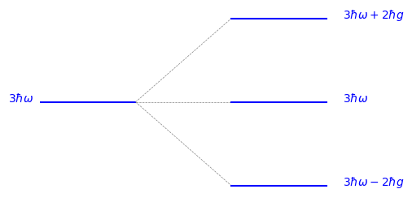

```python
import matplotlib
matplotlib.rcParams.update({'font.size':10})
plt.figure(figsize = (5,3), dpi = 100)
hbb = 1; om = 1; g = 0.1
plt.hlines(3*hbb*om, 0, 0.3, color='blue') # hb*omega := 1
plt.text(-0.1,3*hbb*om,r'$3\hbar\omega$',color='blue')
plt.plot([0.3,0.6],[3*hbb*om,3*hbb*om+2*hbb*g], '--', color='gray', linewidth=0.5)
plt.plot([0.6,0.9],[3*hbb*om+2*hbb*g,3*hbb*om+2*hbb*g], color='blue')
plt.text(0.95,3*hbb*om+2*hbb*g,r'$3\hbar\omega+2\hbar g$',color='blue')
plt.plot([0.3,0.6],[3*hbb*om,3*hbb*om-2*hbb*g], '--', color='gray', linewidth=0.5)
plt.plot([0.6,0.9],[3*hbb*om-2*hbb*g,3*hbb*om-2*hbb*g], color='blue')
plt.text(0.95,3*hbb*om-2*hbb*g,r'$3\hbar\omega-2\hbar g$',color='blue')
plt.plot([0.3,0.6],[3*hbb*om,3*hbb*om], '--', color='gray', linewidth=0.5)
plt.plot([0.6,0.9],[3*hbb*om,3*hbb*om], color='blue')
plt.text(0.95,3*hbb*om,r'$3\hbar\omega$',color='blue')
plt.axis('off'); plt.show()
```

# Exercícios

1. Para espectros discretos degenerados, mostre que as correções de 2ª ordem para a energia são obtidas diagonalizando o operador \begin{equation} H_{2}^{n}=\sum_{m\ne n}\sum_{j=1}^{d_{m}}\frac{H_{1}|\psi_{m,j}^{(0)}\rangle\langle\psi_{m,j}^{(0)}|H_{1}}{E_{n}^{(0)}-E_{m}^{(0)}}. \end{equation}
2. Calcule as correções de 2ª ordem para o oscilador carregado bidimensional em um campo magnético, para o qual $H_{1} = gi\hbar(a_{2}^{\dagger}a_{1} - a_{1}^{\dagger}a_{2})$.